# Caso: Donaciones de Exalumnos

David Moreno, Santiago Amado, Yodid Cardenas

Maestría en Ciencia de Datos

Modelos Estadísticos Aplicados

#### 0.0.0.1 Se lee el archivo desde la ubicación asignado la variable **url**

#### 0.0.0.2 Primeros 5 registros del archivo **contribution**

```
##   Gender Class.Year Marital.Status   Major Next.Degree FY04Giving FY03Giving
## 1      M       1957              M History         LLB       2500       2500
## 2      M       1957              M Physics          MS       5000       5000
## 3      F       1957              M   Music        NONE       5000       5000
## 4      M       1957              M History        NONE          0       5100
## 5      M       1957              M Biology          MD       1000       1000
##   FY02Giving FY01Giving FY00Giving AttendenceEvent
## 1       1400      12060      12000               1
## 2       5000       5000      10000               1
## 3       5000       5000      10000               1
## 4        200        200          0               1
## 5       1000       1005       1000               1
```

# 1 Contextualización.

**Contextualización de datos:** Hay 11 variables en el conjunto de datos con 1230 filas que describen algunos atributos de personas como género, año de graduación, estado marital, área principal de estudio, próximo grado a obtener, y 5 variables adicionales, posiblemente con cantidades en dólares amerícanos, sobre lo que ha donado cada estudiante en un período de 5 años y por último una variable que dice si hubo presencia de la persona en algún evento. De las 11 variables hay 4 de tipo caracter, las otras son de tipo flotante.

Al parecer al evento de donación asistieron personas que se graduaron en 1957, 1967, 1977, 1987 y 1997. La personas que más atendieron el llamado fueron los más recientemente graduados, aunque esto pueda tener que ver con la edad y posible muerte de personas pertenecientes a promociones anteriores.

# 2 Variables de estudio.

El conjunto de datos incluye 1230 registros con 11 variables. Las cuales se describen a continuación:

```
## 'data.frame':    1230 obs. of  11 variables:
##  $ Gender         : chr  "M" "M" "F" "M" ...
##  $ Class.Year     : int  1957 1957 1957 1957 1957 1957 1957 1957 1957 1957 ...
##  $ Marital.Status : chr  "M" "M" "M" "M" ...
##  $ Major          : chr  "History" "Physics" "Music" "History" ...
##  $ Next.Degree    : chr  "LLB" "MS" "NONE" "NONE" ...
##  $ FY04Giving     : num  2500 5000 5000 0 1000 0 0 100 100 0 ...
##  $ FY03Giving     : num  2500 5000 5000 5100 1000 0 0 100 100 0 ...
##  $ FY02Giving     : num  1400 5000 5000 200 1000 0 0 100 100 0 ...
##  $ FY01Giving     : num  12060 5000 5000 200 1005 ...
##  $ FY00Giving     : num  12000 10000 10000 0 1000 0 0 100 100 0 ...
##  $ AttendenceEvent: int  1 1 1 1 1 0 0 0 0 1 ...
```

```
##  [1] "Gender"          "Class.Year"      "Marital.Status"  "Major"
##  [5] "Next.Degree"     "FY04Giving"      "FY03Giving"      "FY02Giving"
##  [9] "FY01Giving"      "FY00Giving"      "AttendenceEvent"
```

[output not shown]

Todas la variables juegan un papel importante para preveer el éxito de futuras campañas de recaudación de fondos.

# 3 Análisis exploratorio.

- Código para visualizar los cinco primeros registros de la base de datos.

```
##   Gender Class.Year Marital.Status   Major Next.Degree FY04Giving FY03Giving
## 1      M       1957              M History         LLB       2500       2500
## 2      M       1957              M Physics          MS       5000       5000
## 3      F       1957              M   Music        NONE       5000       5000
## 4      M       1957              M History        NONE          0       5100
## 5      M       1957              M Biology          MD       1000       1000
##   FY02Giving FY01Giving FY00Giving AttendenceEvent
## 1       1400      12060      12000               1
## 2       5000       5000      10000               1
## 3       5000       5000      10000               1
## 4        200        200          0               1
## 5       1000       1005       1000               1
```

- Se identifica y elimina datos faltantes de la base. Consolidando en una base de datos que no contenga valores perdidos. Se muestra cantidad NA para cada una de las columnas

```
## [1] 0
```

```
##          Gender      Class.Year  Marital.Status           Major     Next.Degree
##               0               0               0               0               0
##      FY04Giving      FY03Giving      FY02Giving      FY01Giving      FY00Giving
##               0               0               0               0               0
## AttendenceEvent
##               0
```

```
## [1] 1230   11
```

- Coerción de variables en la cual se usa al función **as.factor**,es una forma de coerción explícita, donde forzamos la conversión de un tipo de dato a otro. Esto es útil cuando necesitas trabajar con datos categóricos en análisis estadísticos o visualizaciones.

```
## 'data.frame':    1230 obs. of  11 variables:
##  $ Gender         : Factor w/ 2 levels "F","M": 2 2 1 2 2 1 1 1 2 2 ...
##  $ Class.Year     : int  1957 1957 1957 1957 1957 1957 1957 1957 1957 1957 ...
##  $ Marital.Status : Factor w/ 4 levels "D","M","S","W": 2 2 2 2 2 2 3 2 2 2 ...
##  $ Major          : Factor w/ 46 levels "American Studies",..: 26 34 30 26 4 28 26 30 42 16 ...
##  $ Next.Degree    : Factor w/ 50 levels "AA","BA","BAE",..: 17 37 42 42 26 42 19 42 42 42 ...
##  $ FY04Giving     : num  2500 5000 5000 0 1000 0 0 100 100 0 ...
##  $ FY03Giving     : num  2500 5000 5000 5100 1000 0 0 100 100 0 ...
##  $ FY02Giving     : num  1400 5000 5000 200 1000 0 0 100 100 0 ...
##  $ FY01Giving     : num  12060 5000 5000 200 1005 ...
##  $ FY00Giving     : num  12000 10000 10000 0 1000 0 0 100 100 0 ...
##  $ AttendenceEvent: int  1 1 1 1 1 0 0 0 0 1 ...
```

# 4 Análisis descriptivo.

- En la siguiente grafica de barras se puede visualizar cuántos exalumnos se tienen por cohorte.

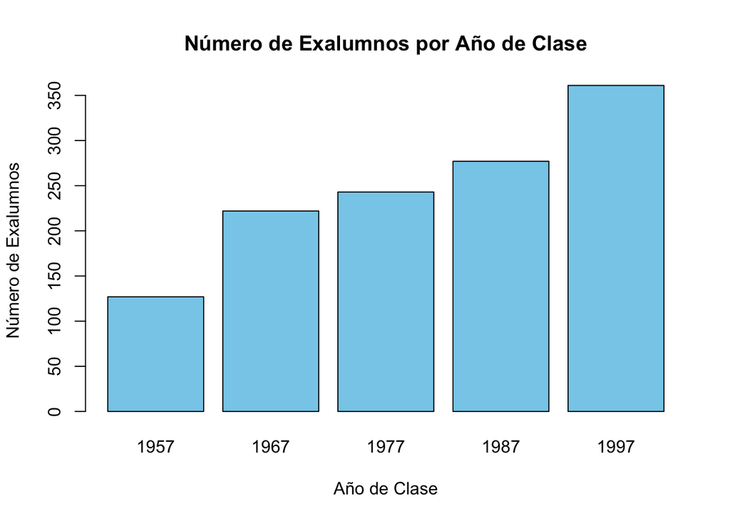

Estadísticos descriptivos de Tgiving

| Estadístico | Valor |
| --- | --- |
| Media | 980.04 |
| Mediana | 75.00 |
| Desviación estándar | 6670.77 |
| Coeficiente de variación (%) | 680.66 |
| Mínimo | 0.00 |
| Máximo | 171870.06 |

**Interpretación:**

Hay una gran diferencia entre la media y la mediana en los datos, esto indica que pueden haber unos pocos valores muy altos en las donaciones, casi que considerandolos atípicos comparados con el comportamiento genérico del resto de la población.

- Determinar los deciles correspondientes a las observaciones de la variable contribuciones totales (variable **TGiving**) e interpreten los resultados que obtienen.

```
##    10%    20%    30%    40%    50%    60%    70%    80%    90%
##    0.0    0.0    0.0   25.0   75.0  150.8  275.0  554.2 1050.0
```

**Interpretation:** Se muestra una gran variabilidad entre el percentil 100 y el percentil 50. Esto sugiere que hay unas pocas contribuciones muy altas, lo cual concuerda con los datos anteriormente analizados a través de la diferencia entre la media y la mediana.

- Tener en cuenta que hay un número considerable de exalumnos que no han contribuido y unos pocos que han realizado aportes muy altos. Por ello, es pertinente excluir del análisis contribuciones totales que sean $0 o superiores a $4000. Esto permite focalizar el análisis en las donaciones más frecuentes de los exalumnos. Construyan un histograma junto con la función de densidad, para visualizar las contribuciones totales (variable **TGiving**) excluyendo los valores descritos. Interpreten los resultados a la luz del contexto.

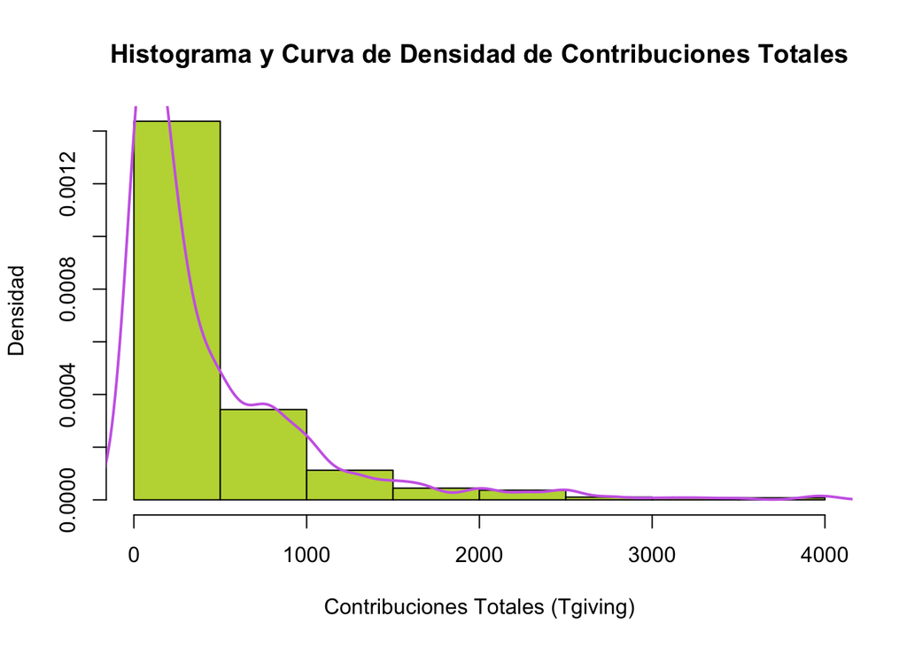

- Describir las características de los exalumnos que han realizado las contribuciones más altas durante el 2000 y 2004. Para ello seleccionen los egresados que hicieron una contribución total (variable **TGiving**) de al menos $20000 durante el periodo de interés.

```
##     Gender Class.Year Marital.Status               Major Next.Degree FY04Giving
## 1        M       1957              M             History         LLB    2500.00
## 2        M       1957              M             Physics          MS    5000.00
## 3        F       1957              M               Music        NONE    5000.00
## 99       M       1957              M Mathematics-Physics        NONE       0.00
## 105      M       1957              M             History         PHD   11505.84
##     FY03Giving FY02Giving FY01Giving FY00Giving AttendenceEvent   Tgiving
## 1         2500       1400    12060.0      12000               1  30460.00
## 2         5000       5000     5000.0      10000               1  30000.00
## 3         5000       5000     5000.0      10000               1  30000.00
## 99        2500       2000   161370.1       6000               1 171870.06
## 105      10000      10000        0.0      20000               1  51505.84
```

```
##
## 1957 1967 1977
##    6    2    2
```

```
##
## M D W S
## 8 1 1 0
```

```
##
##                   History                 Economics        Economics-Business
##                         3                         2                         1
##       Mathematics-Physics                     Music                   Physics
##                         1                         1                         1
##      Speech (Drama, etc.)          American Studies              Anthropology
##                         1                         0                         0
##                       Art                   Biology                 Chemistry
##                         0                         0                         0
##         Chemistry-Zoology                   Chinese                  Classics
##                         0                         0                         0
##    Comparative Literature          Computer Science  Economics-Regional Stds.
##                         0                         0                         0
##                 Education               Engineering                   English
##                         0                         0                         0
##        English-Journalism                    French           General Science
##                         0                         0                         0
##   General Science-Biology General Science-Chemistry      General Science-Math
##                         0                         0                         0
##   General Science-Physics    General Science-Psycho                    German
##                         0                         0                         0
##               Independent               Mathematics                Philosophy
##                         0                         0                         0
##       Philosophy-Religion        Physical Education  Pol. Sci.-Regional Stds.
##                         0                         0                         0
##         Political Science                Psychology         Religious Studies
##                         0                         0                         0
##                   Russian                 Sociology    Sociology-Anthropology
##                         0                         0                         0
##                   Spanish         Speech Correction                   Theatre
##                         0                         0                         0
##                   Zoology
##                         0
```

```
##
##   JD  MBA NONE  LLB   MS  PHD   AA   BA  BAE   BD  BFA   BN   BS BSE2  BSN   DC
##    3    2    2    1    1    1    0    0    0    0    0    0    0    0    0    0
##  DDS  DMD   DO  DO2   DP  LLD   MA  MA2  MAE MALS  MAT  MCP   MD  MD2   ME  ME2
##    0    0    0    0    0    0    0    0    0    0    0    0    0    0    0    0
##  MFA  MHA   ML  MLS   MM  MPA  MPH  MSE  MSM  MSW  NDA  STM   TC UBDS UDDS  UMD
##    0    0    0    0    0    0    0    0    0    0    0    0    0    0    0    0
## UMDS UNKD
##    0    0
```

- Elaborar diagramas de caja que permita comparar la donación total (variable **TGiving**) durante los 5 años discriminando por cohorte, género, estado civil y asistencia a eventos de recaudación de fondos. Con la opción **outline** omitan las observaciones periféricas (datos atípicos, es decir, aquellos donantes que contribuyen generosamente). Comparen los cuatro gráficos, destaquen diferencias y similitudes entre grupos.

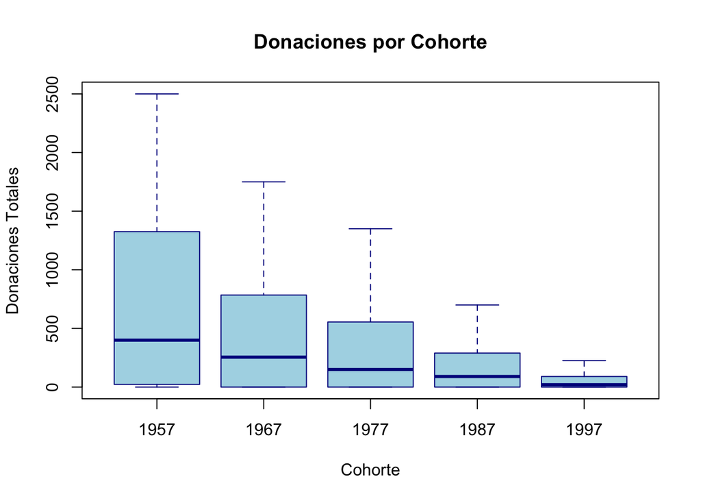

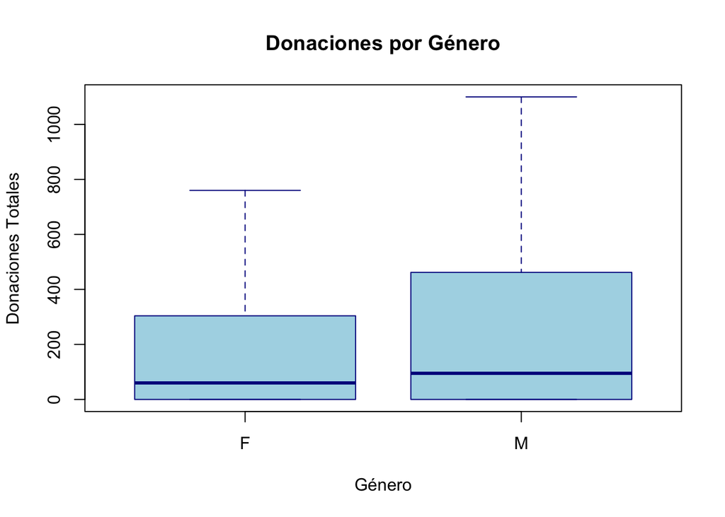

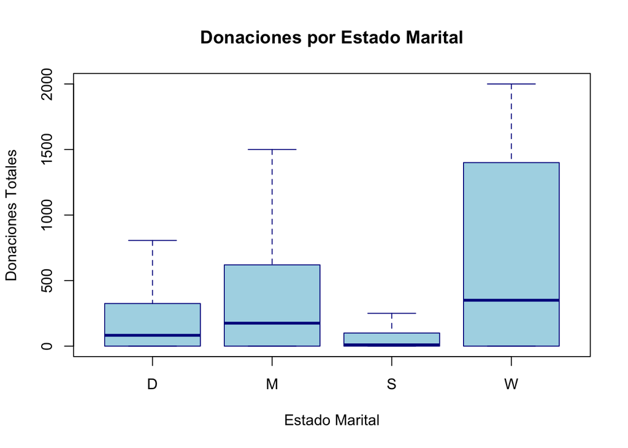

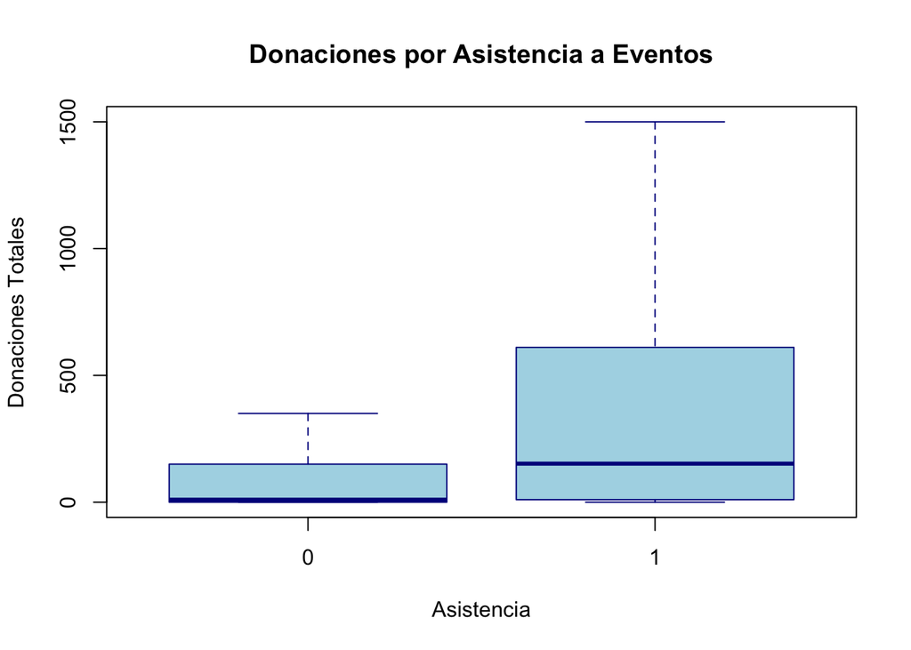

- Construir una tabla que de cuenta del número de estudiantes y el promedio del total de contribuciones (variable **TGiving**) por carrera universitaria. ¿Cuáles son las carreras que tienen un mayor número de exalumnos en la base de datos? ¿cuáles son las que tienen una contribución total promedio más alta? Para calcular promedio por grupos pueden utilizar la función **tapply()**.

```
## [1] "Número de Estudiantes por Carrera y Promedio de Contribuciones"
```

```
##                      Carrera Numero_Estudiantes Promedio_Contribuciones
## 26                   History                135               1782.3447
## 16                   English                123                397.1862
## 4                    Biology                115                551.0024
## 11                 Economics                 87               1166.9149
## 36         Political Science                 81                719.0517
## 37                Psychology                 79                554.5177
## 5                  Chemistry                 63                421.8368
## 40                 Sociology                 57                626.9218
## 2               Anthropology                 44                164.2500
## 28               Mathematics                 44                501.2500
## 3                        Art                 39                164.0769
## 30                     Music                 30               1221.9000
## 1           American Studies                 29                451.2845
## 42                   Spanish                 27                211.4815
```

[output cut: 32 more lines]

```
## [1] "Carreras con la Contribución Total Promedio más Alta"
```

```
##                      Carrera Numero_Estudiantes Promedio_Contribuciones
## 29       Mathematics-Physics                  3              57570.0200
## 6          Chemistry-Zoology                  3              11083.3333
## 43      Speech (Drama, etc.)                  7              10699.3300
## 12        Economics-Business                 24               4334.6617
## 17        English-Journalism                  1               1897.4400
## 33        Physical Education                  5               1886.0000
## 34                   Physics                 21               1842.1429
## 26                   History                135               1782.3447
## 30                     Music                 30               1221.9000
## 11                 Economics                 87               1166.9149
## 8                   Classics                  9                767.0000
## 10          Computer Science                  4                737.0000
## 36         Political Science                 81                719.0517
## 40                 Sociology                 57                626.9218
```

[output cut: 32 more lines]

- Crear una variable indicadora (pueden denominarla **TGivingIND**) que clasifique los exalumnos en contribuyentes (1) y no contribuyentes (0). Utilizando esta variable elaboren un mosaico para visualizar la proporción de contribuyentes por cohorte y otro para visualizar la proporción según la asistencia a eventos. Interpreten lo que observan en estos gráficos.

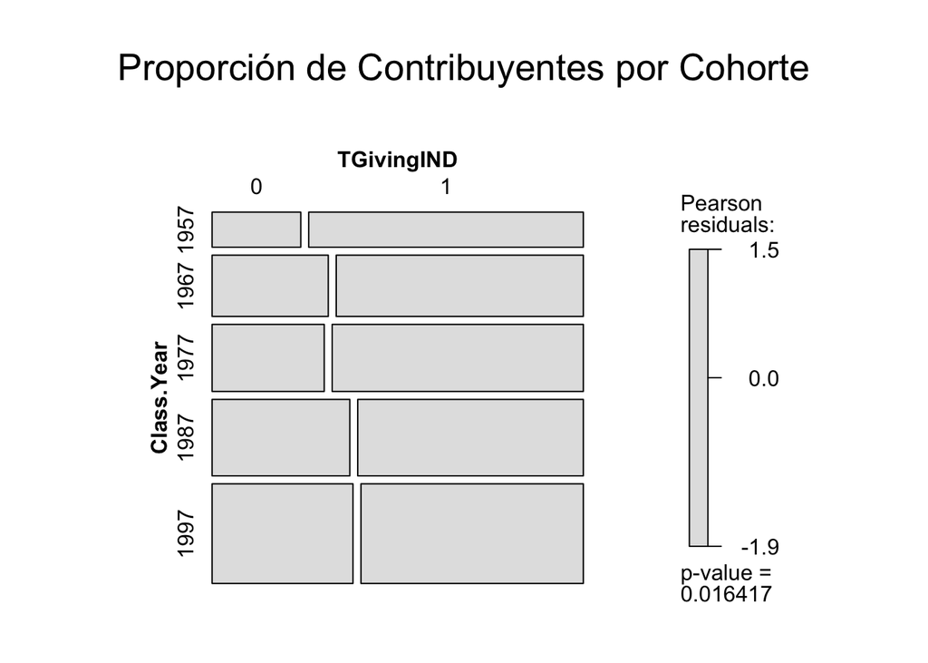

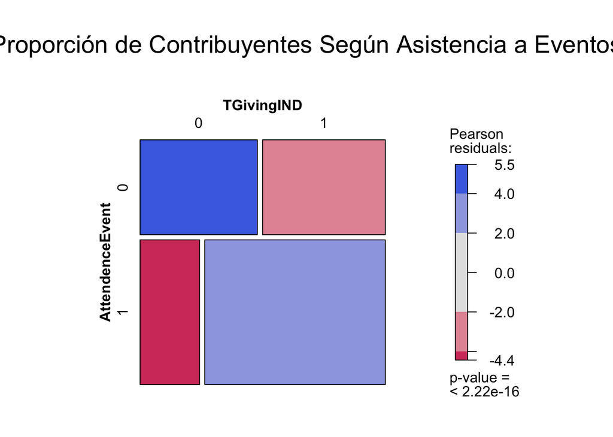

# 5 Discusión.

**1. Aspectos a Considerar en la Próxima Campaña de Recaudación de Fondos**

Basados en la evidencia empírica proporcionada por los datos, se identificaron varios patrones que los encargados de la recaudación de fondos deben considerar en futuras campañas. Primero, la asistencia a eventos se muestra como un factor clave para fomentar las donaciones; aquellos exalumnos que asistieron a eventos presentan una mayor probabilidad de contribuir. Por lo tanto, una estrategia efectiva sería aumentar la promoción y el alcance de estos eventos, personalizando las invitaciones y destacando la importancia del impacto de las donaciones en la universidad. Además, es crucial segmentar las campañas por cohorte, ya que ciertas generaciones muestran mayor afinidad hacia la contribución. Personalizar los mensajes para conectar emocionalmente con estas cohortes específicas puede incrementar el compromiso y, por ende, las donaciones.

**2. Aspectos No Examinados y Mejoras en la Caracterización de Contribuyentes**

El análisis descriptivo realizado brinda un panorama general de los patrones de donación, pero hay aspectos que no fueron examinados y que podrían fortalecer la toma de decisiones. No se consideraron variables cualitativas relacionadas con la experiencia universitaria, como la participación en clubes o actividades extracurriculares, que podrían influir en la propensión a donar. Tampoco se evaluaron las comunicaciones previas entre los exalumnos y la universidad, como correos o campañas anteriores, para analizar cómo impactaron en la conducta de donación. Mejorar la segmentación de los donantes con base en factores socioeconómicos, como ocupación y nivel de ingresos, podría también proporcionar un enfoque más preciso en la identificación de posibles grandes contribuyentes. Integrar estas dimensiones podría permitir una caracterización más robusta del perfil de los donantes.

**3. Recomendaciones de Nuevas Variables para Mejorar el Análisis**

Para identificar exalumnos con mayor potencial de donación, se recomienda incorporar variables adicionales como `Ingreso Anual`, `Industria de Trabajo`, `Participación en Actividades Universitarias`, `Frecuencia de Contacto con la Universidad` y `Motivaciones para Donar`. La inclusión de `Ingreso Anual` y `Industria de Trabajo` permitiría identificar aquellos exalumnos que tienen mayor capacidad económica y que podrían ser abordados con campañas específicas de alto valor. La `Participación en Actividades Universitarias` podría ayudar a entender mejor la conexión emocional con la universidad, mientras que la `Frecuencia de Contacto con la Universidad` ofrecería información valiosa sobre el nivel de compromiso y predisposición a donar. Finalmente, explorar las `Motivaciones para Donar`, como reconocimiento o gratitud, podría guiar las estrategias para personalizar las campañas y maximizar su efectividad.